# Multiple linear regression and binary logistic regression models

Abdellah AitElmouden | Gabriel Abreu | Jered Ataky | Patrick Maloney

4/13/2021

## Overview

This assignment is about to explore, to analyze and to model a data set containing approximately 8000 records representing a customer at an auto insurance company. Each record has two response variables. The first response variable, TARGET_FLAG, is a 1 or a 0. A “1” means that the person was in a car crash. A zero means that the person was not in a car crash. The second response variable is TARGET_AMT. This value is zero if the person did not crash their car. But if they did crash their car, this number will be a value greater than zero. Your objective is to build multiple linear regression and binary logistic regression models on the df1ing data to predict the probability that a person will crash their car and also the amount of money it will cost if the person does crash their car. You can only use the variables given to you (or variables that you derive from the variables provided).

## Data exploration

### Outliers

The following diagram shows the outliers for all the variables(numerical), both dependent and independent.

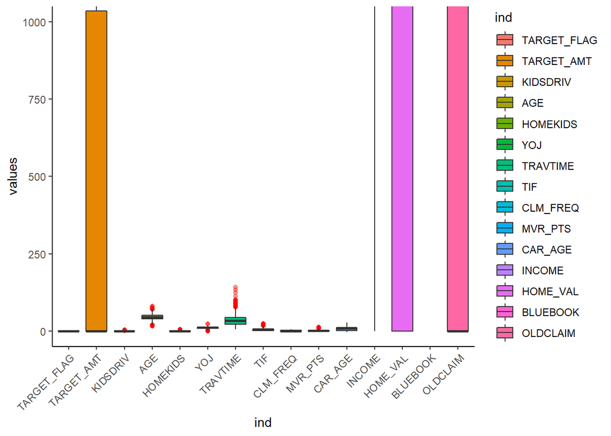

### Correlation

Below is the correlation between the numerical variables…

```
##             TARGET_FLAG  TARGET_AMT     KIDSDRIV          AGE     HOMEKIDS
## TARGET_FLAG  1.00000000  0.53992929  0.097295404 -0.103649398  0.115481537
## TARGET_AMT   0.53992929  1.00000000  0.056857228 -0.046745810  0.068857861
## KIDSDRIV     0.09729540  0.05685723  1.000000000 -0.072361631  0.463046635
## AGE         -0.10364940 -0.04674581 -0.072361631  1.000000000 -0.442383841
## HOMEKIDS     0.11548154  0.06885786  0.463046635 -0.442383841  1.000000000
## YOJ         -0.06658661 -0.02144631  0.048112090  0.139566052  0.090416449
## TRAVTIME     0.05149130  0.03270817  0.008979590  0.004555303 -0.007787772
## TIF         -0.07718644 -0.04525925 -0.003423442  0.002871951  0.004673246
## CLM_FREQ     0.22338169  0.11515694  0.035087170 -0.026312189  0.030695809
## MVR_PTS      0.22526236  0.13770829  0.055019621 -0.073523273  0.062776101
## CAR_AGE     -0.10435770 -0.06283345 -0.055877063  0.182184524 -0.156534495
##                     YOJ     TRAVTIME          TIF     CLM_FREQ      MVR_PTS
## TARGET_FLAG -0.06658661  0.051491295 -0.077186438  0.223381685  0.225262361
## TARGET_AMT  -0.02144631  0.032708168 -0.045259254  0.115156936  0.137708292
## KIDSDRIV     0.04811209  0.008979590 -0.003423442  0.035087170  0.055019621
## AGE          0.13956605  0.004555303  0.002871951 -0.026312189 -0.073523273
## HOMEKIDS     0.09041645 -0.007787772  0.004673246  0.030695809  0.062776101
## YOJ          1.00000000 -0.015762889  0.029302946 -0.030658029 -0.039172617
## TRAVTIME    -0.01576289  1.000000000 -0.009343232  0.009306981  0.009937566
## TIF          0.02930295 -0.009343232  1.000000000 -0.024972898 -0.037174513
## CLM_FREQ    -0.03065803  0.009306981 -0.024972898  1.000000000  0.400121265
## MVR_PTS     -0.03917262  0.009937566 -0.037174513  0.400121265  1.000000000
## CAR_AGE      0.06122969 -0.037055196  0.009125709 -0.011538390 -0.019363647
##                  CAR_AGE
## TARGET_FLAG -0.104357704
## TARGET_AMT  -0.062833451
## KIDSDRIV    -0.055877063
## AGE          0.182184524
## HOMEKIDS    -0.156534495
## YOJ          0.061229694
## TRAVTIME    -0.037055196
## TIF          0.009125709
## CLM_FREQ    -0.011538390
## MVR_PTS     -0.019363647
## CAR_AGE      1.000000000
```

Here’s the correlation matrix visualization…

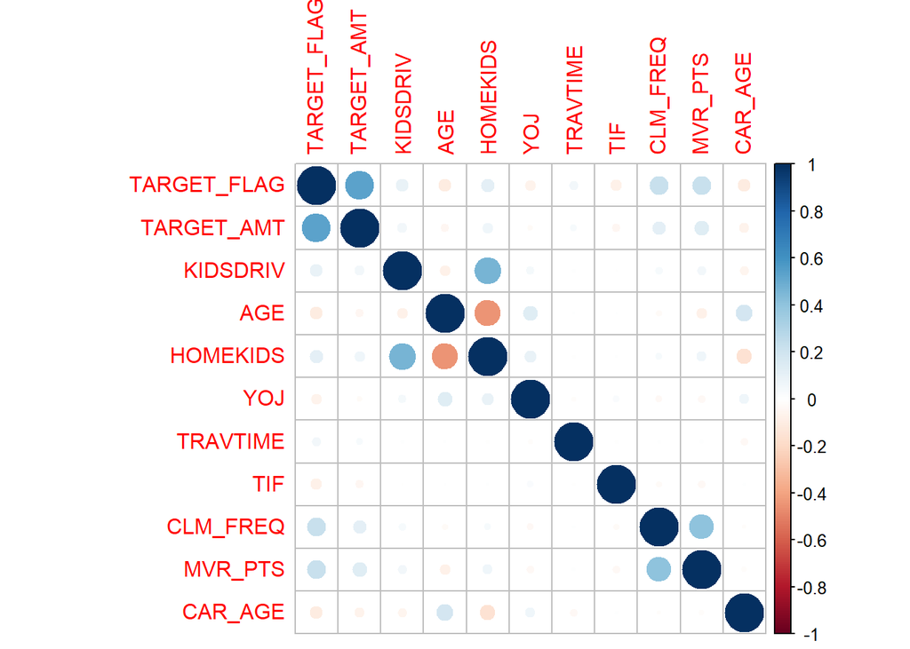

There is a little bit of correlation between HomeKids and Kidsdriv, and MVR_PTS and CLM_FREQ

## Data Preparation

### Missing values

Let explore the number of missing values in each variable

```
##     CAR_AGE    HOME_VAL         YOJ      INCOME         AGE  URBANICITY
##         510         464         454         445           6           0
##    CAR_TYPE         JOB   EDUCATION         SEX     MSTATUS    OLDCLAIM
##           0           0           0           0           0           0
##    BLUEBOOK     MVR_PTS     REVOKED    CLM_FREQ     RED_CAR         TIF
##           0           0           0           0           0           0
##     CAR_USE    TRAVTIME     PARENT1    HOMEKIDS    KIDSDRIV  TARGET_AMT
##           0           0           0           0           0           0
## TARGET_FLAG
##           0
```

```
## [1] 1879
```

We will use mean and BoxCox transformation for data imputation, but we need to transform little the data for BoxCox transformation… BoxCox needs variable to have value greater or equal to 1

### BoxCox iputation prep

Prepare for BoxCox imputation…

```
##           TARGET_FLAG            TARGET_AMT              KIDSDRIV
##                   "0"        "     0.00000"                   "0"
##                   AGE              HOMEKIDS                   YOJ
##                  "16"                   "0"                  " 0"
##               PARENT1              TRAVTIME               CAR_USE
##                  "No"                 "  5"          "Commercial"
##                   TIF               RED_CAR              CLM_FREQ
##                  " 1"                  "no"                   "0"
##               REVOKED               MVR_PTS               CAR_AGE
##                  "No"                  " 0"                    NA
##                INCOME              HOME_VAL              BLUEBOOK
##              "     0"              "     0"               " 1500"
##              OLDCLAIM               MSTATUS                   SEX
##               "    0"                  "No"                   "F"
##             EDUCATION                   JOB              CAR_TYPE
##        "<High School"                    ""             "Minivan"
##            URBANICITY
## "Highly Rural/ Rural"
```

```
## $TIF
## Box-Cox Transformation
##
## 7650 data points used to estimate Lambda
##
## Input data summary:
##    Min. 1st Qu.  Median    Mean 3rd Qu.    Max.
##    1.00    1.00    4.00    5.36    7.00   25.00
##
## Largest/Smallest: 25
## Sample Skewness: 0.89
##
## Estimated Lambda: 0.2
##
##
## $BLUEBOOK
## Box-Cox Transformation
##
## 7650 data points used to estimate Lambda
##
## Input data summary:
##    Min. 1st Qu.  Median    Mean 3rd Qu.    Max.
##    1500    9315   14440   15720   20820   69740
##
## Largest/Smallest: 46.5
## Sample Skewness: 0.802
##
## Estimated Lambda: 0.5
##
##
## $TRAVTIME
## Box-Cox Transformation
##
## 7650 data points used to estimate Lambda
##
## Input data summary:
##    Min. 1st Qu.  Median    Mean 3rd Qu.    Max.
##    5.00   23.00   33.00   33.55   44.00  142.00
##
## Largest/Smallest: 28.4
```

[output cut: 49 more lines]

```
##
##
## $INCOME
## Box-Cox Transformation
##
## 7650 data points used to estimate Lambda
##
## Input data summary:
##    Min. 1st Qu.  Median    Mean 3rd Qu.    Max.
##       1   29701   54029   61450   83302  367031
##
## Largest/Smallest: 367000
## Sample Skewness: 1.25
##
## Estimated Lambda: 0.4
```

## Build Models

### Multiple Linear Regression Models

#### Model 1: Mean full model

Building the first model using all the variables…

```
##
## Call:
## lm(formula = TARGET_AMT ~ ., data = df_lm)
##
## Residuals:
##    Min     1Q Median     3Q    Max
##  -8934  -3199  -1537    493  99141
##
## Coefficients:
##                                 Estimate Std. Error t value Pr(>|t|)
## (Intercept)                    3.025e+03  2.095e+03   1.444 0.148807
## KIDSDRIV                      -1.167e+02  3.378e+02  -0.346 0.729696
## AGE                            1.272e+01  2.236e+01   0.569 0.569617
## HOMEKIDS                       2.288e+02  2.169e+02   1.055 0.291669
## YOJ                            2.451e+01  5.173e+01   0.474 0.635662
## PARENT1Yes                     1.406e+02  6.166e+02   0.228 0.819623
## TRAVTIME                       3.617e+00  1.169e+01   0.309 0.757114
## CAR_USEPrivate                -5.479e+02  5.487e+02  -0.999 0.318094
## TIF                           -3.882e+01  4.482e+01  -0.866 0.386583
## RED_CARyes                    -2.473e+02  5.214e+02  -0.474 0.635302
## CLM_FREQ                      -1.463e+02  1.662e+02  -0.880 0.378836
## REVOKEDYes                    -1.192e+03  5.427e+02  -2.197 0.028162 *
## MVR_PTS                        1.088e+02  7.231e+01   1.504 0.132743
## CAR_AGE                       -9.230e+01  4.617e+01  -1.999 0.045712 *
## INCOME                        -9.670e-03  7.073e-03  -1.367 0.171729
## HOME_VAL                       1.671e-03  2.112e-03   0.791 0.429070
## BLUEBOOK                       1.227e-01  3.196e-02   3.840 0.000127 ***
## OLDCLAIM                       3.257e-02  2.364e-02   1.378 0.168373
## MSTATUSYes                    -8.493e+02  5.218e+02  -1.628 0.103786
## SEXM                           1.397e+03  6.880e+02   2.030 0.042451 *
## EDUCATIONBachelors             2.182e+02  6.777e+02   0.322 0.747551
## EDUCATIONHigh School          -5.850e+02  5.389e+02  -1.086 0.277780
## EDUCATIONMasters               9.636e+02  1.152e+03   0.836 0.403142
## EDUCATIONPhD                   2.460e+03  1.396e+03   1.762 0.078207 .
## JOBBlue Collar                 6.499e+02  1.205e+03   0.539 0.589660
## JOBClerical                    3.778e+02  1.263e+03   0.299 0.764818
## JOBDoctor                     -2.073e+03  1.812e+03  -1.144 0.252835
## JOBHome Maker                  1.686e+02  1.333e+03   0.126 0.899392
## JOBLawyer                      4.172e+02  1.075e+03   0.388 0.697950
## JOBManager                    -7.283e+02  1.128e+03  -0.646 0.518587
## JOBProfessional                1.389e+03  1.181e+03   1.176 0.239802
## JOBStudent                     1.484e+02  1.355e+03   0.110 0.912816
## CAR_TYPEPanel Truck           -5.584e+02  1.004e+03  -0.556 0.578258
## CAR_TYPEPickup                -2.292e+02  6.279e+02  -0.365 0.715141
## CAR_TYPESports Car             1.074e+03  7.867e+02   1.365 0.172386
## CAR_TYPESUV                    9.386e+02  6.968e+02   1.347 0.178104
## CAR_TYPEVan                    3.322e+02  8.104e+02   0.410 0.681889
## URBANICITYHighly Urban/ Urban  1.499e+02  7.962e+02   0.188 0.850687
## ---
## Signif. codes:  0 '***' 0.001 '**' 0.01 '*' 0.05 '.' 0.1 ' ' 1
##
## Residual standard error: 7817 on 1973 degrees of freedom
##   (142 observations deleted due to missingness)
## Multiple R-squared:  0.03181,    Adjusted R-squared:  0.01366
## F-statistic: 1.752 on 37 and 1973 DF,  p-value: 0.003512
```

Visualization…

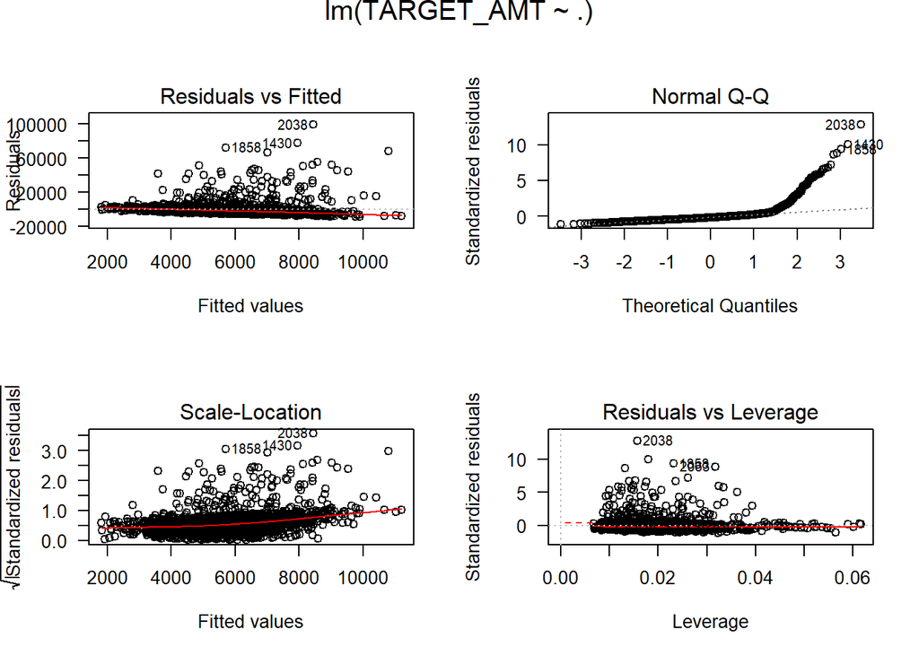

#### Model 2: Stepwise

```
## Start:  AIC=36091.11
## TARGET_AMT ~ KIDSDRIV + AGE + HOMEKIDS + YOJ + PARENT1 + TRAVTIME +
##     CAR_USE + TIF + RED_CAR + CLM_FREQ + REVOKED + MVR_PTS +
##     CAR_AGE + INCOME + HOME_VAL + BLUEBOOK + OLDCLAIM + MSTATUS +
##     SEX + EDUCATION + JOB + CAR_TYPE + URBANICITY
##
##              Df Sum of Sq        RSS   AIC
## - JOB         8 469943135 1.2103e+11 36083
## - CAR_TYPE    5 253319413 1.2082e+11 36085
## - URBANICITY  1   2165878 1.2057e+11 36089
## - PARENT1     1   3178268 1.2057e+11 36089
## - TRAVTIME    1   5846477 1.2057e+11 36089
## - KIDSDRIV    1   7297697 1.2057e+11 36089
## - YOJ         1  13720342 1.2058e+11 36089
## - RED_CAR     1  13749572 1.2058e+11 36089
## - AGE         1  19763912 1.2058e+11 36089
## - HOME_VAL    1  38228288 1.2060e+11 36090
## - EDUCATION   4 405041171 1.2097e+11 36090
## - TIF         1  45829844 1.2061e+11 36090
## - CLM_FREQ    1  47346961 1.2061e+11 36090
## - CAR_USE     1  60940121 1.2062e+11 36090
## - HOMEKIDS    1  67981141 1.2063e+11 36090
## - INCOME      1 114217654 1.2068e+11 36091
## - OLDCLAIM    1 116027467 1.2068e+11 36091
## <none>                    1.2056e+11 36091
## - MVR_PTS     1 138223654 1.2070e+11 36091
## - MSTATUS     1 161861282 1.2073e+11 36092
## - CAR_AGE     1 244258656 1.2081e+11 36093
## - SEX         1 251910571 1.2082e+11 36093
## - REVOKED     1 294856563 1.2086e+11 36094
## - BLUEBOOK    1 901120949 1.2146e+11 36104
##
## Step:  AIC=36082.94
## TARGET_AMT ~ KIDSDRIV + AGE + HOMEKIDS + YOJ + PARENT1 + TRAVTIME +
##     CAR_USE + TIF + RED_CAR + CLM_FREQ + REVOKED + MVR_PTS +
##     CAR_AGE + INCOME + HOME_VAL + BLUEBOOK + OLDCLAIM + MSTATUS +
##     SEX + EDUCATION + CAR_TYPE + URBANICITY
##
##              Df Sum of Sq        RSS   AIC
## - CAR_TYPE    5 236966467 1.2127e+11 36077
```

[output cut: 347 more lines]

```
## - MVR_PTS   1  202828770 1.2212e+11 36055
## - BLUEBOOK  1 1746551592 1.2367e+11 36080
##
## Step:  AIC=36052.26
## TARGET_AMT ~ REVOKED + MVR_PTS + CAR_AGE + BLUEBOOK + MSTATUS +
##     SEX
##
##            Df  Sum of Sq        RSS   AIC
## <none>                   1.2196e+11 36052
## - CAR_AGE   1  140440225 1.2210e+11 36053
## - REVOKED   1  141378251 1.2210e+11 36053
## - MSTATUS   1  164261705 1.2212e+11 36053
## - SEX       1  188329377 1.2215e+11 36053
## - MVR_PTS   1  210544699 1.2217e+11 36054
## - BLUEBOOK  1 1724209476 1.2368e+11 36078
```

```
##
## Call:
## lm(formula = TARGET_AMT ~ REVOKED + MVR_PTS + CAR_AGE + BLUEBOOK +
##     MSTATUS + SEX, data = df_lm)
##
## Residuals:
##    Min     1Q Median     3Q    Max
##  -8263  -3162  -1574    325 100465
##
## Coefficients:
##               Estimate Std. Error t value Pr(>|t|)
## (Intercept) 4281.91344  503.98221   8.496  < 2e-16 ***
## REVOKEDYes  -656.16299  430.50600  -1.524   0.1276
## MVR_PTS      125.73815   67.60109   1.860   0.0630 .
## CAR_AGE      -48.79606   32.12165  -1.519   0.1289
## BLUEBOOK       0.11376    0.02137   5.323 1.14e-07 ***
## MSTATUSYes  -573.12750  348.85252  -1.643   0.1006
## SEXM         618.26245  351.45734   1.759   0.0787 .
## ---
## Signif. codes:  0 '***' 0.001 '**' 0.01 '*' 0.05 '.' 0.1 ' ' 1
##
## Residual standard error: 7801 on 2004 degrees of freedom
##   (142 observations deleted due to missingness)
## Multiple R-squared:  0.02061,    Adjusted R-squared:  0.01767
## F-statistic: 7.027 on 6 and 2004 DF,  p-value: 2.043e-07
```

#### Model 3: BoxCox imputation

```
##
## Call:
## lm(formula = TARGET_AMT ~ KIDSDRIV + AGE + HOMEKIDS + I(YOJ^1.6) +
##     PARENT1 + I(TRAVTIME^0.7) + CAR_USE + I(TIF^0.2) + RED_CAR +
##     CLM_FREQ + REVOKED + MVR_PTS + I(CAR_AGE^0.5) + I(INCOME^0.4) +
##     HOME_VAL + I(BLUEBOOK^0.5) + OLDCLAIM + MSTATUS + SEX + EDUCATION +
##     JOB + CAR_TYPE + URBANICITY, data = df_lm)
##
## Residuals:
##    Min     1Q Median     3Q    Max
##  -8792  -3250  -1499    530  99271
##
## Coefficients:
##                                 Estimate Std. Error t value Pr(>|t|)
## (Intercept)                    1.950e+03  2.476e+03   0.788   0.4310
## KIDSDRIV                      -1.437e+02  3.390e+02  -0.424   0.6717
## AGE                            1.214e+01  2.265e+01   0.536   0.5921
## HOMEKIDS                       2.291e+02  2.205e+02   1.039   0.2989
## I(YOJ^1.6)                     1.451e+00  9.802e+00   0.148   0.8823
## PARENT1Yes                     1.700e+02  6.172e+02   0.276   0.7830
## I(TRAVTIME^0.7)                1.111e+01  4.701e+01   0.236   0.8132
## CAR_USEPrivate                -4.413e+02  5.489e+02  -0.804   0.4214
## I(TIF^0.2)                    -4.381e+02  7.321e+02  -0.598   0.5497
## RED_CARyes                    -2.595e+02  5.217e+02  -0.497   0.6190
## CLM_FREQ                      -1.520e+02  1.663e+02  -0.914   0.3610
## REVOKEDYes                    -1.167e+03  5.430e+02  -2.149   0.0317 *
## MVR_PTS                        1.135e+02  7.243e+01   1.566   0.1174
## I(CAR_AGE^0.5)                -3.511e+02  2.122e+02  -1.655   0.0982 .
## I(INCOME^0.4)                 -2.820e+00  1.120e+01  -0.252   0.8012
## HOME_VAL                       1.132e-03  2.066e-03   0.548   0.5837
## I(BLUEBOOK^0.5)                2.917e+01  7.245e+00   4.026 5.89e-05 ***
## OLDCLAIM                       3.307e-02  2.366e-02   1.397   0.1624
## MSTATUSYes                    -7.339e+02  5.226e+02  -1.404   0.1604
## SEXM                           1.386e+03  6.789e+02   2.042   0.0413 *
## EDUCATIONBachelors             1.807e+01  6.843e+02   0.026   0.9789
## EDUCATIONHigh School          -6.488e+02  5.425e+02  -1.196   0.2319
## EDUCATIONMasters               4.820e+02  1.130e+03   0.426   0.6699
## EDUCATIONPhD                   1.746e+03  1.349e+03   1.294   0.1957
## JOBBlue Collar                 7.549e+02  1.200e+03   0.629   0.5294
## JOBClerical                    5.742e+02  1.255e+03   0.457   0.6474
## JOBDoctor                     -2.158e+03  1.814e+03  -1.189   0.2345
## JOBHome Maker                  4.477e+02  1.391e+03   0.322   0.7477
## JOBLawyer                      4.032e+02  1.074e+03   0.375   0.7075
## JOBManager                    -7.432e+02  1.129e+03  -0.659   0.5103
## JOBProfessional                1.439e+03  1.179e+03   1.221   0.2223
## JOBStudent                     4.161e+02  1.411e+03   0.295   0.7681
## CAR_TYPEPanel Truck           -3.759e+02  9.639e+02  -0.390   0.6966
## CAR_TYPEPickup                -1.729e+02  6.290e+02  -0.275   0.7835
## CAR_TYPESports Car             1.111e+03  7.840e+02   1.417   0.1567
## CAR_TYPESUV                    9.021e+02  6.886e+02   1.310   0.1903
## CAR_TYPEVan                    2.934e+02  8.101e+02   0.362   0.7172
## URBANICITYHighly Urban/ Urban  9.856e+01  7.962e+02   0.124   0.9015
## ---
## Signif. codes:  0 '***' 0.001 '**' 0.01 '*' 0.05 '.' 0.1 ' ' 1
##
## Residual standard error: 7821 on 1972 degrees of freedom
##   (143 observations deleted due to missingness)
## Multiple R-squared:  0.03108,    Adjusted R-squared:  0.0129
## F-statistic:  1.71 on 37 and 1972 DF,  p-value: 0.00508
```

Residual analysis…

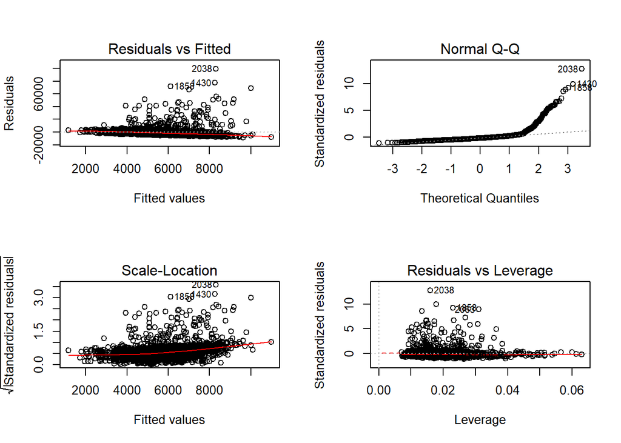

### Logistic Regression Models

#### Model 1: Mean full model

Let build the first full model for logistiv regression…

```
##
## Call:
## glm(formula = TARGET_FLAG ~ ., family = "binomial", data = df_rm)
##
## Deviance Residuals:
##     Min       1Q   Median       3Q      Max
## -2.5654  -0.7168  -0.3972   0.6148   3.1535
##
## Coefficients:
##                                 Estimate Std. Error z value Pr(>|z|)
## (Intercept)                   -2.994e+00  3.520e-01  -8.506  < 2e-16 ***
## KIDSDRIV                       3.455e-01  6.381e-02   5.414 6.16e-08 ***
## AGE                            3.193e-04  4.145e-03   0.077 0.938603
## HOMEKIDS                       6.304e-02  3.822e-02   1.649 0.099118 .
## YOJ                           -1.136e-02  8.872e-03  -1.280 0.200450
## PARENT1Yes                     3.853e-01  1.131e-01   3.406 0.000659 ***
## TRAVTIME                       1.492e-02  1.953e-03   7.641 2.16e-14 ***
## CAR_USEPrivate                -7.534e-01  9.459e-02  -7.965 1.65e-15 ***
## TIF                           -5.512e-02  7.590e-03  -7.261 3.83e-13 ***
## RED_CARyes                     1.800e-03  8.927e-02   0.020 0.983911
## CLM_FREQ                       2.025e-01  2.938e-02   6.892 5.51e-12 ***
## REVOKEDYes                     8.804e-01  9.439e-02   9.327  < 2e-16 ***
## MVR_PTS                        1.142e-01  1.405e-02   8.132 4.22e-16 ***
## CAR_AGE                       -4.559e-03  7.797e-03  -0.585 0.558745
## INCOME                        -3.107e-06  1.116e-06  -2.783 0.005386 **
## HOME_VAL                      -1.290e-06  3.525e-07  -3.658 0.000254 ***
## BLUEBOOK                      -2.147e-05  5.439e-06  -3.949 7.86e-05 ***
## OLDCLAIM                      -1.288e-05  4.011e-06  -3.211 0.001324 **
## MSTATUSYes                    -4.902e-01  8.656e-02  -5.663 1.49e-08 ***
## SEXM                           8.549e-02  1.154e-01   0.741 0.458957
## EDUCATIONBachelors            -3.626e-01  1.198e-01  -3.027 0.002470 **
## EDUCATIONHigh School           3.528e-02  9.786e-02   0.361 0.718470
## EDUCATIONMasters              -2.129e-01  1.865e-01  -1.141 0.253692
## EDUCATIONPhD                  -1.214e-01  2.231e-01  -0.544 0.586367
## JOBBlue Collar                 3.198e-01  1.922e-01   1.664 0.096189 .
## JOBClerical                    4.362e-01  2.034e-01   2.144 0.031997 *
## JOBDoctor                     -3.528e-01  2.716e-01  -1.299 0.193892
## JOBHome Maker                  2.764e-01  2.176e-01   1.270 0.204072
## JOBLawyer                      1.035e-01  1.749e-01   0.592 0.554008
## JOBManager                    -6.151e-01  1.784e-01  -3.449 0.000563 ***
## JOBProfessional                1.439e-01  1.842e-01   0.781 0.434798
## JOBStudent                     1.991e-01  2.226e-01   0.894 0.371160
## CAR_TYPEPanel Truck            6.109e-01  1.669e-01   3.661 0.000251 ***
## CAR_TYPEPickup                 5.267e-01  1.041e-01   5.058 4.24e-07 ***
## CAR_TYPESports Car             9.979e-01  1.341e-01   7.440 1.01e-13 ***
## CAR_TYPESUV                    7.535e-01  1.147e-01   6.570 5.03e-11 ***
## CAR_TYPEVan                    5.872e-01  1.304e-01   4.503 6.71e-06 ***
## URBANICITYHighly Urban/ Urban  2.373e+00  1.164e-01  20.385  < 2e-16 ***
## ---
## Signif. codes:  0 '***' 0.001 '**' 0.01 '*' 0.05 '.' 0.1 ' ' 1
##
## (Dispersion parameter for binomial family taken to be 1)
##
##     Null deviance: 8814.1  on 7650  degrees of freedom
## Residual deviance: 6831.7  on 7613  degrees of freedom
##   (510 observations deleted due to missingness)
## AIC: 6907.7
##
## Number of Fisher Scoring iterations: 5
```

Confusion matrix and the curve…

[figure not shown]

```r
probabilities <- predict(rm_model1, df_rm, type = "response")
predicted1.classes <- ifelse(probabilities > 0.5, 1, 0)
df_rm$pred1.class <- predicted1.classes
table("Predictions" = df_rm$pred1.class, "Actual" = df_rm$TARGET_FLAG)
```

```
##            Actual
## Predictions    0    1
##           0 5216 1172
##           1  424  839
```

```
## Confusion Matrix and Statistics
##
##           Reference
## Prediction    0    1
##          0 5216 1172
##          1  424  839
##
##                Accuracy : 0.7914
##                  95% CI : (0.7821, 0.8005)
##     No Information Rate : 0.7372
##     P-Value [Acc > NIR] : < 2.2e-16
##
##                   Kappa : 0.3885
##
##  Mcnemar's Test P-Value : < 2.2e-16
##
##             Sensitivity : 0.9248
##             Specificity : 0.4172
##          Pos Pred Value : 0.8165
##          Neg Pred Value : 0.6643
##              Prevalence : 0.7372
##          Detection Rate : 0.6817
##    Detection Prevalence : 0.8349
##       Balanced Accuracy : 0.6710
##
##        'Positive' Class : 0
##
```

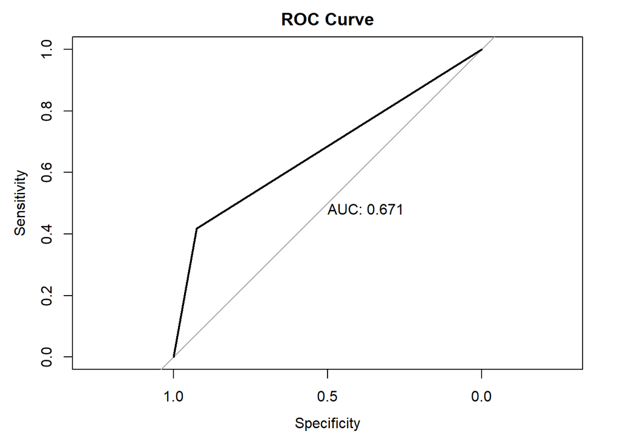

#### Model 2: Random forest

Logistic regression with Random forest…

```
##
## Call:
##  randomForest(formula = factor(TARGET_FLAG) ~ ., data = rf_train,      na.action = na.omit)
##                Type of random forest: classification
##                      Number of trees: 500
## No. of variables tried at each split: 4
##
##         OOB estimate of  error rate: 21.5%
## Confusion matrix:
##      0   1 class.error
## 0 4202 293  0.06518354
## 1 1023 604  0.62876460
```

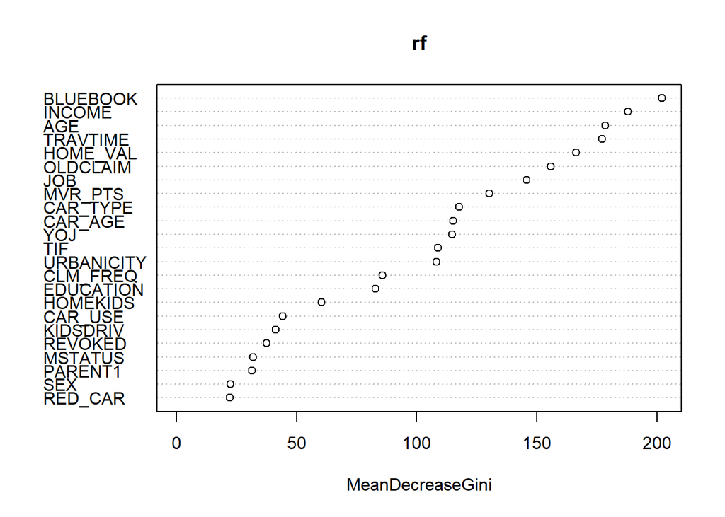

Confusion matrix…

```
## Confusion Matrix and Statistics
##
##           Reference
## Prediction    0    1
##          0 1070  243
##          1   75  141
##
##                Accuracy : 0.792
##                  95% CI : (0.7708, 0.8121)
##     No Information Rate : 0.7489
##     P-Value [Acc > NIR] : 4.115e-05
##
##                   Kappa : 0.353
##
##  Mcnemar's Test P-Value : < 2.2e-16
##
##             Sensitivity : 0.36719
##             Specificity : 0.93450
##          Pos Pred Value : 0.65278
##          Neg Pred Value : 0.81493
##              Prevalence : 0.25114
##          Detection Rate : 0.09222
##    Detection Prevalence : 0.14127
##       Balanced Accuracy : 0.65084
##
##        'Positive' Class : 1
##
```

#### Model 3: Stepwise

The stepwise model…

```
## Start:  AIC=5564.81
## TARGET_FLAG ~ KIDSDRIV + AGE + HOMEKIDS + YOJ + PARENT1 + TRAVTIME +
##     CAR_USE + TIF + RED_CAR + CLM_FREQ + REVOKED + MVR_PTS +
##     CAR_AGE + INCOME + HOME_VAL + BLUEBOOK + OLDCLAIM + MSTATUS +
##     SEX + EDUCATION + JOB + CAR_TYPE + URBANICITY
##
##              Df Deviance    AIC
## - AGE         1   5488.8 5562.8
## - RED_CAR     1   5488.8 5562.8
## - SEX         1   5489.2 5563.2
## - YOJ         1   5489.5 5563.5
## - CAR_AGE     1   5489.6 5563.6
## <none>            5488.8 5564.8
## - HOMEKIDS    1   5491.2 5565.2
## - OLDCLAIM    1   5495.7 5569.7
## - INCOME      1   5499.0 5573.0
## - HOME_VAL    1   5499.5 5573.5
## - EDUCATION   4   5506.2 5574.2
## - PARENT1     1   5501.9 5575.9
## - BLUEBOOK    1   5507.1 5581.1
## - KIDSDRIV    1   5509.5 5583.5
## - MSTATUS     1   5510.6 5584.6
## - CLM_FREQ    1   5521.8 5595.8
## - JOB         8   5536.0 5596.0
## - TRAVTIME    1   5533.2 5607.2
## - CAR_TYPE    5   5542.5 5608.5
## - CAR_USE     1   5538.7 5612.7
## - MVR_PTS     1   5539.6 5613.6
## - TIF         1   5544.1 5618.1
## - REVOKED     1   5547.4 5621.4
## - URBANICITY  1   5987.1 6061.1
##
## Step:  AIC=5562.81
## TARGET_FLAG ~ KIDSDRIV + HOMEKIDS + YOJ + PARENT1 + TRAVTIME +
##     CAR_USE + TIF + RED_CAR + CLM_FREQ + REVOKED + MVR_PTS +
##     CAR_AGE + INCOME + HOME_VAL + BLUEBOOK + OLDCLAIM + MSTATUS +
##     SEX + EDUCATION + JOB + CAR_TYPE + URBANICITY
##
##              Df Deviance    AIC
## - RED_CAR     1   5488.8 5560.8
```

[output cut: 121 more lines]

```
## - INCOME      1   5501.7 5565.7
## - PARENT1     1   5504.2 5568.2
## - EDUCATION   4   5514.1 5572.1
## - KIDSDRIV    1   5512.5 5576.5
## - MSTATUS     1   5513.5 5577.5
## - BLUEBOOK    1   5516.9 5580.9
## - JOB         8   5537.7 5587.7
## - CLM_FREQ    1   5523.8 5587.8
## - TRAVTIME    1   5535.1 5599.1
## - CAR_USE     1   5540.9 5604.9
## - MVR_PTS     1   5542.4 5606.4
## - CAR_TYPE    5   5551.2 5607.2
## - TIF         1   5546.5 5610.5
## - REVOKED     1   5549.7 5613.7
## - URBANICITY  1   5989.6 6053.6
```

```
##
## Call:
## glm(formula = TARGET_FLAG ~ KIDSDRIV + HOMEKIDS + PARENT1 + TRAVTIME +
##     CAR_USE + TIF + CLM_FREQ + REVOKED + MVR_PTS + INCOME + HOME_VAL +
##     BLUEBOOK + OLDCLAIM + MSTATUS + EDUCATION + JOB + CAR_TYPE +
##     URBANICITY, family = "binomial", data = no_na_df)
##
## Deviance Residuals:
##     Min       1Q   Median       3Q      Max
## -2.5388  -0.7167  -0.3954   0.6413   3.1311
##
## Coefficients:
##                                 Estimate Std. Error z value Pr(>|z|)
## (Intercept)                   -2.735e+00  3.204e-01  -8.538  < 2e-16 ***
## KIDSDRIV                       3.281e-01  7.042e-02   4.660 3.17e-06 ***
## HOMEKIDS                       5.966e-02  3.870e-02   1.542 0.123192
## PARENT1Yes                     4.582e-01  1.252e-01   3.660 0.000252 ***
## TRAVTIME                       1.451e-02  2.185e-03   6.640 3.14e-11 ***
## CAR_USEPrivate                -7.386e-01  1.051e-01  -7.027 2.11e-12 ***
## TIF                           -6.213e-02  8.506e-03  -7.304 2.79e-13 ***
## CLM_FREQ                       1.881e-01  3.251e-02   5.787 7.18e-09 ***
## REVOKEDYes                     8.186e-01  1.057e-01   7.746 9.48e-15 ***
## MVR_PTS                        1.127e-01  1.576e-02   7.151 8.63e-13 ***
## INCOME                        -4.047e-06  1.237e-06  -3.271 0.001073 **
## HOME_VAL                      -1.276e-06  3.946e-07  -3.234 0.001222 **
## BLUEBOOK                      -2.765e-05  5.487e-06  -5.040 4.66e-07 ***
## OLDCLAIM                      -1.173e-05  4.452e-06  -2.636 0.008397 **
## MSTATUSYes                    -4.614e-01  9.631e-02  -4.791 1.66e-06 ***
## EDUCATIONBachelors            -3.685e-01  1.247e-01  -2.955 0.003129 **
## EDUCATIONHigh School           9.227e-02  1.087e-01   0.849 0.395887
## EDUCATIONMasters              -2.755e-01  1.862e-01  -1.480 0.138960
## EDUCATIONPhD                  -2.494e-01  2.316e-01  -1.077 0.281630
## JOBBlue Collar                 2.396e-01  2.167e-01   1.106 0.268822
## JOBClerical                    2.895e-01  2.291e-01   1.264 0.206303
## JOBDoctor                     -2.506e-01  3.021e-01  -0.830 0.406734
## JOBHome Maker                  1.716e-01  2.381e-01   0.721 0.470913
## JOBLawyer                      1.536e-02  1.950e-01   0.079 0.937207
## JOBManager                    -6.526e-01  2.010e-01  -3.247 0.001165 **
## JOBProfessional                2.182e-02  2.072e-01   0.105 0.916118
## JOBStudent                     6.000e-02  2.455e-01   0.244 0.806933
## CAR_TYPEPanel Truck            6.856e-01  1.733e-01   3.957 7.59e-05 ***
## CAR_TYPEPickup                 4.974e-01  1.159e-01   4.292 1.77e-05 ***
## CAR_TYPESports Car             8.126e-01  1.245e-01   6.526 6.77e-11 ***
## CAR_TYPESUV                    5.899e-01  9.799e-02   6.020 1.74e-09 ***
## CAR_TYPEVan                    5.494e-01  1.421e-01   3.867 0.000110 ***
## URBANICITYHighly Urban/ Urban  2.391e+00  1.285e-01  18.609  < 2e-16 ***
## ---
## Signif. codes:  0 '***' 0.001 '**' 0.01 '*' 0.05 '.' 0.1 ' ' 1
##
## (Dispersion parameter for binomial family taken to be 1)
##
##     Null deviance: 7089.3  on 6121  degrees of freedom
## Residual deviance: 5490.8  on 6089  degrees of freedom
## AIC: 5556.8
##
## Number of Fisher Scoring iterations: 5
```

Confusion matrix and the curve…

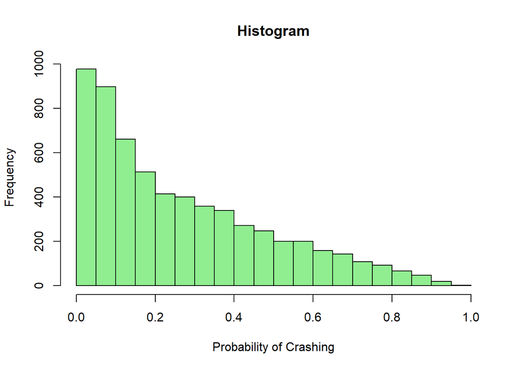

```
##            Actual
## Predictions    0    1
##           0 1122  249
##           1   91  170
```

```
## Confusion Matrix and Statistics
##
##           Reference
## Prediction    0    1
##          0 1122  249
##          1   91  170
##
##                Accuracy : 0.7917
##                  95% CI : (0.7711, 0.8111)
##     No Information Rate : 0.7433
##     P-Value [Acc > NIR] : 2.754e-06
##
##                   Kappa : 0.3773
##
##  Mcnemar's Test P-Value : < 2.2e-16
##
##             Sensitivity : 0.4057
##             Specificity : 0.9250
##          Pos Pred Value : 0.6513
##          Neg Pred Value : 0.8184
##              Prevalence : 0.2567
##          Detection Rate : 0.1042
##    Detection Prevalence : 0.1599
##       Balanced Accuracy : 0.6654
##
##        'Positive' Class : 1
##
```

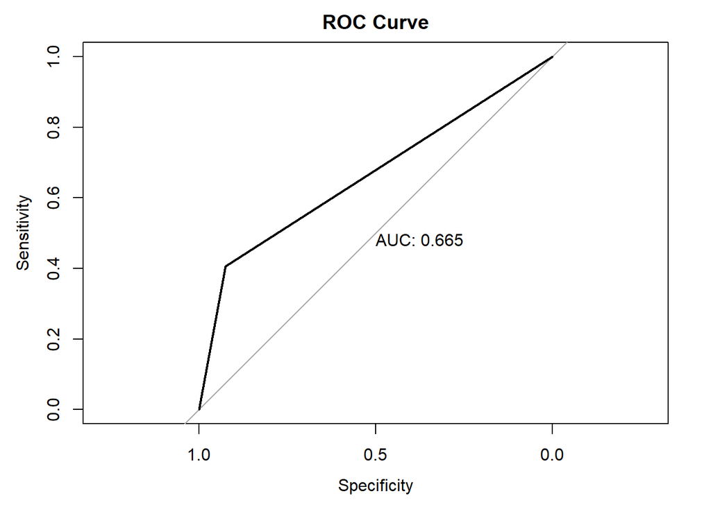

## Select Models

|  | TARGET_FLAG | TARGET_AMT | KIDSDRIV | AGE | HOMEKIDS | YOJ | PARENT1 | TRAVTIME | CAR_USE | TIF | RED_CAR | CLM_FREQ | REVOKED | MVR_PTS | CAR_AGE | INCOME | HOME_VAL | BLUEBOOK | OLDCLAIM | MSTATUS | SEX | EDUCATION | JOB | CAR_TYPE | URBANICITY |
| --- | --- | --- | --- | --- | --- | --- | --- | --- | --- | --- | --- | --- | --- | --- | --- | --- | --- | --- | --- | --- | --- | --- | --- | --- | --- |
| 1 | NA | NA | 0 | 48 | 0 | 11 | No | 26 | Private | 1 | yes | 0 | No | 2 | 10 | 52881 | 0 | 21970 | 0 | No | M | Bachelors | Manager | Van | Highly Urban/ Urban |
| 2 | NA | NA | 1 | 40 | 1 | 11 | Yes | 21 | Private | 6 | no | 1 | No | 2 | 1 | 50815 | 0 | 18930 | 3295 | No | M | High School | Manager | Minivan | Highly Urban/ Urban |
| 3 | NA | NA | 0 | 44 | 2 | 12 | Yes | 30 | Commercial | 10 | no | 0 | No | 0 | 10 | 43486 | 0 | 5900 | 0 | No | F | High School | Blue Collar | SUV | Highly Rural/ Rural |
| 4 | NA | NA | 0 | 35 | 2 | NA | Yes | 74 | Private | 6 | no | 0 | Yes | 0 | 4 | 21204 | 0 | 9230 | 0 | No | M | High School | Clerical | Pickup | Highly Rural/ Rural |
| 5 | NA | NA | 0 | 59 | 0 | 12 | No | 45 | Private | 1 | yes | 2 | No | 4 | 1 | 87460 | 0 | 15420 | 44857 | No | M | High School | Manager | Minivan | Highly Urban/ Urban |
| 6 | NA | NA | 0 | 46 | 0 | 14 | No | 7 | Commercial | 1 | no | 1 | No | 2 | 12 | NA | 207519 | 25660 | 2119 | Yes | M | Bachelors | Professional | Panel Truck | Highly Urban/ Urban |

### Does the person crash the car?

The following shows if a person crash his or her car…

```
##    1    2    3    4    5    6    7    8    9   10   11   12   13   14   15   16
##    0    0    0    0    0    0    0    0    0    0    0    1    1    0    0    1
##   17   18   19   20   21   22   23   24   25   26   27   28   29   30   31   32
##    1    0    1    0    0    0    0    0    0    0    0    0    0    0    0    0
##   33   34   35   36   37   38   39   40   41   42   43   44   45   46   47   48
##    0    0    0    0    0    0    0    1    0    1    0    1    0    0    0    0
##   49   50   51   52   53   54   55   56   57   58   59   60   61   62   63   64
##    0    1    0    0    1    0    0    0    0    0    0    1    0    0    0    0
##   65   66   67   68   69   70   71   72   73   74   75   76   77   78   79   80
##    0    0    1    1    0    0    0    0    1    0    1    0    0    0    0    0
##   81   82   83   84   85   86   87   88   89   90   91   92   93   94   95   96
##    1    0    0    0    0    1    0    0    0    1    0    0    0    0    0    0
##   97   98   99  100  101  102  103  104  105  106  107  108  109  110  111  112
##    0    0    0    0    0    1    1    1    0    0    0    0    0    0    1    0
##  113  114  115  116  117  118  119  120  121  122  123  124  125  126  127  128
```

[output cut: 253 more lines]

### What’s the pay off?

The following shows the pay off for the person who has a crash car…

```
##        1        2        3        4        5        6        7        8
##    0.000    0.000    0.000    0.000    0.000    0.000    0.000    0.000
##        9       10       11       12       13       14       15       16
##    0.000    0.000    0.000 5475.670       NA    0.000    0.000 5696.563
##       17       18       19       20       21       22       23       24
##       NA    0.000 4005.702    0.000    0.000    0.000    0.000    0.000
##       25       26       27       28       29       30       31       32
##    0.000    0.000    0.000    0.000    0.000    0.000    0.000    0.000
##       33       34       35       36       37       38       39       40
##    0.000    0.000    0.000    0.000    0.000    0.000    0.000 5773.914
##       41       42       43       44       45       46       47       48
##    0.000 5222.274    0.000 6895.830    0.000    0.000    0.000    0.000
##       49       50       51       52       53       54       55       56
##    0.000 4122.707    0.000    0.000 6354.033    0.000    0.000    0.000
##       57       58       59       60       61       62       63       64
##    0.000    0.000    0.000 3956.597    0.000    0.000    0.000    0.000
##       65       66       67       68       69       70       71       72
##    0.000    0.000 5079.031 7313.395    0.000    0.000    0.000    0.000
##       73       74       75       76       77       78       79       80
## 5291.526    0.000 5617.353    0.000    0.000    0.000    0.000    0.000
##       81       82       83       84       85       86       87       88
## 4258.968    0.000    0.000    0.000    0.000 6707.825    0.000    0.000
##       89       90       91       92       93       94       95       96
##    0.000 6004.846    0.000    0.000    0.000    0.000    0.000    0.000
##       97       98       99      100      101      102      103      104
##    0.000    0.000    0.000    0.000    0.000 6769.367 6191.289 6218.239
##      105      106      107      108      109      110      111      112
##    0.000    0.000    0.000    0.000    0.000    0.000 5465.364    0.000
##      113      114      115      116      117      118      119      120
##    0.000    0.000 5368.212    0.000    0.000 5420.656 3319.370    0.000
##      121      122      123      124      125      126      127      128
##    0.000 5301.919 4497.096    0.000    0.000    0.000    0.000    0.000
##      129      130      131      132      133      134      135      136
##    0.000    0.000    0.000    0.000    0.000    0.000    0.000    0.000
##      137      138      139      140      141      142      143      144
## 6802.093 6829.302    0.000    0.000    0.000 5537.473    0.000    0.000
##      145      146      147      148      149      150      151      152
##    0.000 4494.962    0.000    0.000    0.000    0.000 6005.710    0.000
##      153      154      155      156      157      158      159      160
## 6369.258    0.000    0.000    0.000    0.000    0.000 5348.406 5846.070
```

[output cut: 481 more lines]

```
##    0.000    0.000    0.000    0.000    0.000    0.000    0.000    0.000
##     2089     2090     2091     2092     2093     2094     2095     2096
##    0.000 4799.944    0.000    0.000    0.000    0.000    0.000 4751.927
##     2097     2098     2099     2100     2101     2102     2103     2104
##    0.000    0.000 8334.052 4442.980       NA    0.000 5388.466    0.000
##     2105     2106     2107     2108     2109     2110     2111     2112
##    0.000    0.000 4656.371    0.000    0.000    0.000 5244.470    0.000
##     2113     2114     2115     2116     2117     2118     2119     2120
##    0.000    0.000    0.000    0.000 5813.373    0.000 4787.678    0.000
##     2121     2122     2123     2124     2125     2126     2127     2128
##    0.000    0.000 6373.741    0.000    0.000    0.000    0.000    0.000
##     2129     2130     2131     2132     2133     2134     2135     2136
##    0.000    0.000    0.000    0.000    0.000    0.000    0.000    0.000
##     2137     2138     2139     2140     2141
##    0.000    0.000    0.000    0.000    0.000
```

## Appendix

### References

- [Regression Model Validation](http://www.sthda.com/english/articles/38-regression-model-validation/158-regression-model-accuracy-metrics-r-square-aic-bic-cp-and-more/)
- [Binary Logistic Regression](https://towardsdatascience.com/implementing-binary-logistic-regression-in-r-7d802a9d98fe)
- [What are pseudo R-squareds?] (https://stats.idre.ucla.edu/other/mult-pkg/faq/general/faq-what-are-pseudo-r-squareds/)